# Evaluation of Water Temperature

# Business Problem

- Power Plant face environmental constraints that affect efficiency and can lead to failure to meet demands
- Power Plants rely on cooling to stay at a functional level
- Global Warming elevates these constraints by making cooling systems less efficient

## Context

Temperatures above 85°F create operation risk and forces reduced efficiency

## Goal

- Assess likelihood of reduced capacity
- Evaluate the impact of running at reduced capacity
- Project the risk and impact over the next 5 years

# Data Overview

- NOAA water temperature data at the Dauphin Island Station
- EIA energy generation data at the James M. Barry Electric Generating Plant
- EIA energy demand data from the Alabama Power Company

NOAA (National Oceanic and Atmospheric Administration) https://tidesandcurrents.noaa.gov/physocean.html?i d=8735180 EIA (Energy Information Administration) https://www.eia.gov/electricity/data/eia861m/ EIA (Energy Information Administration) https://www.eia.gov/beta/electricity/data/browser/#/plant/3?f req=M&start=202001&end=202512&ctype=linechart&ltype=pin&tab=generation&columnchart=ELEC.PLANT.GEN.3-ALL-ALL.M&maptype=0&pin=&linechart=

# Methodology

## Approach 1

1. Monthly Averages were calculated using confidence intervals
2. Defined risk levels based on proportion of days above 85°F in water temperature
3. Used linear regressions for temperature predictions

## Approach 2

1. Calculated average contribution
2. Energy generation was compared to consumption
3. Evaluated impact of running at reduced capacity

## Finding 1

Peak month temperatures:

- July *86.62°F (95% CI: 86.57-86.68)*
- August *86.35°F* *(95% CI: 86.31-86.38)*

High Risk months:

- July *(72.7%)*
- August *(73.6%)*

Moderate Risk months:

- June *(45.5%)*
- September *(32%)*

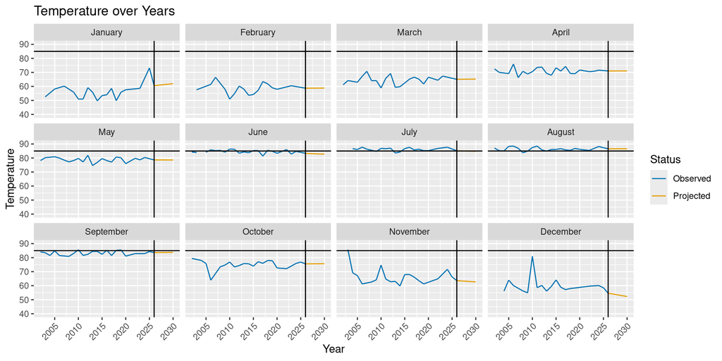

## Finding 2

Defined Contribution: *10.3%*

Most impacted month: *50* of capacity April of 2023

[figure not shown]

# Interpretation

- Power plant can cover reduced capacity of up to 30%
- Reduced Capacity likely needed during high and moderate risk months
- Failure to meet demand can be offset due to system

# Limitations

- Missing Data
- Lack of context
- Programming Errors

# Recommendations

- Operate at reduced capacity from June-September
- Expand analysis to include power plants under Alabama Power Company
- Monitor increasing temperature and energy demand